# Big Mart Sales Prediction

数据来源:https://datahack.analyticsvidhya.com/contest/practice-problem-big-mart-sales-iii/

## 分析目的：

通过给定信息 探索影响销售额的因素 预测特定商品在特定商店的销售额。

数据说明：

[figure not shown]

## 一、导入数据

```python
import numpy as np
import pandas as pd
from pandas import Series,DataFrame
import seaborn as sns
sns.set_style("whitegrid")
import matplotlib.pyplot as plt
%matplotlib inline

import warnings
warnings.filterwarnings('ignore')
```

```python
train_raw = pd.read_csv("D:/Projects/AnacondaProjects/Big Mart Sales/train.csv")
test_raw = pd.read_csv("D:/Projects/AnacondaProjects/Big Mart Sales/test.csv")
# 这里把两个数据集放在同一起 便于一起进行特征工程
test_raw["Item_Outlet_Sales"] = np.nan
all_data = train_raw.append( test_raw , ignore_index = True )
print(train_raw.shape)
print(test_raw.shape)
```

```
(8523, 12)
(5681, 12)
```

训练集一共8523 条数据，测试集一共5681条数据

### 数据概况

```python
all_data.info()
```

```
<class 'pandas.core.frame.DataFrame'>
RangeIndex: 14204 entries, 0 to 14203
Data columns (total 12 columns):
Item_Identifier              14204 non-null object
Item_Weight                  11765 non-null float64
Item_Fat_Content             14204 non-null object
Item_Visibility              14204 non-null float64
Item_Type                    14204 non-null object
Item_MRP                     14204 non-null float64
Outlet_Identifier            14204 non-null object
Outlet_Establishment_Year    14204 non-null int64
Outlet_Size                  10188 non-null object
Outlet_Location_Type         14204 non-null object
Outlet_Type                  14204 non-null object
Item_Outlet_Sales            8523 non-null float64
dtypes: float64(4), int64(1), object(7)
memory usage: 1.3+ MB
```

一共有11个特征，其中Item_Weight 和Outlet_Size 含有缺失值 Item_Outlet_Sales 缺失值和测试集数据大小相符合

```python
all_data.describe()
```

|  | Item_Weight | Item_Visibility | Item_MRP | Outlet_Establishment_Year | Item_Outlet_Sales |
| --- | --- | --- | --- | --- | --- |
| count | 11765.000000 | 14204.000000 | 14204.000000 | 14204.000000 | 8523.000000 |
| mean | 12.792854 | 0.065953 | 141.004977 | 1997.830681 | 2181.288914 |
| std | 4.652502 | 0.051459 | 62.086938 | 8.371664 | 1706.499616 |
| min | 4.555000 | 0.000000 | 31.290000 | 1985.000000 | 33.290000 |
| 25% | 8.710000 | 0.027036 | 94.012000 | 1987.000000 | 834.247400 |
| 50% | 12.600000 | 0.054021 | 142.247000 | 1999.000000 | 1794.331000 |
| 75% | 16.750000 | 0.094037 | 185.855600 | 2004.000000 | 3101.296400 |
| max | 21.350000 | 0.328391 | 266.888400 | 2009.000000 | 13086.964800 |

从表中可以发现 商品重量分布在 4.5 - 21.5 之间，不存特别异常的重量，符合超市的常见货品重量范围； 商品可见性方面范围在 0 - 0.33 这里的 0 ，我们猜想三种因素 第一种：因为该商品占比太小，比如超市中的口香糖，所以近似等于0， 第二种：商品比较偏，需求量特别小，摆出来性价比不高，需要顾客询问。 第三种：异常数据，需要处理 针对这项数据我们后期会加以关注。 标签价格范围在 31 - 267 之间 符合常见货物价格区间 商店建造年份在 1985 - 2009 之间，这项数据我们后期可能会计算出建造年份到数据收集的时间，用以评估超市的新旧等因素。 销售额 分布33 - 13087 ，75%的人消费额在 3101 以下，而最大值达到13000，可见应该是存在单笔金额比较大的订单，该数据是我们最终需要预测的，需要进一步分析。

## 二、数据预处理

### 2.1 缺失值处理

```python
missing_df = all_data.isnull().sum().reset_index()
missing_df.columns = ['columns_name','missing_number']
missing_df['missing_scale'] = missing_df['missing_number']/all_data.shape[0]
miss = missing_df.sort_values('missing_number',ascending = False).reset_index(drop = True)
miss
```

|  | columns_name | missing_number | missing_scale |
| --- | --- | --- | --- |
| 0 | Item_Outlet_Sales | 5681 | 0.399958 |
| 1 | Outlet_Size | 4016 | 0.282737 |
| 2 | Item_Weight | 2439 | 0.171712 |
| 3 | Item_Identifier | 0 | 0.000000 |
| 4 | Item_Fat_Content | 0 | 0.000000 |
| 5 | Item_Visibility | 0 | 0.000000 |
| 6 | Item_Type | 0 | 0.000000 |
| 7 | Item_MRP | 0 | 0.000000 |
| 8 | Outlet_Identifier | 0 | 0.000000 |
| 9 | Outlet_Establishment_Year | 0 | 0.000000 |
| 10 | Outlet_Location_Type | 0 | 0.000000 |
| 11 | Outlet_Type | 0 | 0.000000 |

从统计中可以看到，商品重量和超市规模存在缺失值，销售额的缺失数量和test集相吻合。

#### 2.1.1 Item_Weight

不同店铺销售的同一个商品规格相同，所以用同一商品编号的平均值来填充缺失值

```python
# st = list(all_data[all_data.Item_Weight.isnull()].index)
# s = {}
# for x in st:
#     all_data.Item_Weight[x] = round(all_data[ all_data['Item_Identifier'] ==all_data.loc[x].Item_Identifier].Item_Weight.mean(),2)

Impute_itemWeight = all_data.pivot_table(index = 'Item_Identifier', values = ['Item_Weight'],aggfunc = np.mean)
for i,row in all_data.loc[all_data['Item_Weight'].isnull(), :].iterrows():
    s = row['Item_Identifier']
    all_data.loc[i,'Item_Weight'] = Impute_itemWeight.loc[s].values
```

#### 2.1.2 Outlet_Size

从上面的统计中我们可以看到 size 的缺失值 达到 28.3% 这里我们把size缺失的数据提取出来单独探索

```python
miss_size = all_data[all_data['Outlet_Size'].isnull()]

print(miss_size.pivot_table(index = ['Outlet_Establishment_Year','Outlet_Identifier','Outlet_Location_Type','Outlet_Type'], values = ['Item_Outlet_Sales'],aggfunc = np.mean))
all_data.pivot_table(index = ['Outlet_Establishment_Year','Outlet_Identifier','Outlet_Location_Type','Outlet_Type','Outlet_Size'], values = ['Item_Outlet_Sales'],aggfunc = np.mean)
```

```
                                                                                    Item_Outlet_Sales
Outlet_Establishment_Year Outlet_Identifier Outlet_Location_Type Outlet_Type
1998                      OUT010            Tier 3               Grocery Store             339.351662
2002                      OUT045            Tier 2               Supermarket Type1        2192.384798
2007                      OUT017            Tier 2               Supermarket Type1        2340.675263
```

| Outlet_Establishment_Year | Outlet_Identifier | Outlet_Location_Type | Outlet_Type | Outlet_Size | Item_Outlet_Sales |
| --- | --- | --- | --- | --- | --- |
| 1985 | OUT019 | Tier 1 | Grocery Store | Small | 340.329723 |
|  | OUT027 | Tier 3 | Supermarket Type3 | Medium | 3694.038558 |
| 1987 | OUT013 | Tier 3 | Supermarket Type1 | High | 2298.995256 |
| 1997 | OUT046 | Tier 1 | Supermarket Type1 | Small | 2277.844267 |
| 1999 | OUT049 | Tier 1 | Supermarket Type1 | Medium | 2348.354635 |
| 2004 | OUT035 | Tier 2 | Supermarket Type1 | Small | 2438.841866 |
| 2009 | OUT018 | Tier 3 | Supermarket Type2 | Medium | 1995.498739 |

```python
#每年新建商店数量
all_data.groupby('Outlet_Establishment_Year')['Outlet_Identifier'].count()
```

```
Outlet_Establishment_Year
1985    2439
1987    1553
1997    1550
1998     925
1999    1550
2002    1548
2004    1550
2007    1543
2009    1546
Name: Outlet_Identifier, dtype: int64
```

```python
#不同类型商店的总销售额
all_data.groupby('Outlet_Type')['Item_Outlet_Sales'].sum()
```

```
Outlet_Type
Grocery Store        3.680343e+05
Supermarket Type1    1.291734e+07
Supermarket Type2    1.851823e+06
Supermarket Type3    3.453926e+06
Name: Item_Outlet_Sales, dtype: float64
```

从上面可以看到Grocery 的销售额和其他的店铺查了一个数量级

```python
all_data.groupby('Outlet_Size')['Outlet_Identifier'].count()
```

```
Outlet_Size
High      1553
Medium    4655
Small     3980
Name: Outlet_Identifier, dtype: int64
```

根据我们一般经验，按照规格来说，规格越大 数量越少，说明在缺失数据中存在大量small

从统计信息可以看到： 1、除去1985和 1998 年，各个年份建造的商店数量基本是稳定的，大约在1500 左右 2、除去 1985 年和1998 年两个时间外，其余年份的销售额是基本稳定的，大约在2000 - 2400 之间 也就是说成立时间对销售额的影响不大 3、从1997 和 2004 只有位置不同，然而销售额相差不大，所以单一的商店位置对销售额的改变不大 4、从1997和1985以及 类型与销售额的统计信息，商店的类型对销售额的影响巨大 5、从1997和1999发现 单一的size 改变 对销售额影响不大，但是size 大 销售额会相对大一点

综上 我们对size 的缺失值全部以small 填充

```python
all_data.Outlet_Size.fillna('Small',inplace = True)
```

```python
all_data.Outlet_Size.isnull().sum()
```

```
0
```

### 2.2 异常值处理

#### 2.2.1 Item_Visibility

之前曾观察到，visibility 的最小值是0 并有三种猜想，现在我们深入探讨。

```python
Outlier_Visibility = all_data[all_data['Item_Visibility'] == 0]
print(Outlier_Visibility.Item_Outlet_Sales.mean())
print(Outlier_Visibility.Item_Identifier.count())
```

```
2222.5429281368824
879
```

从平均销售额我们可以看到达到 2222.54 甚至高于所有商品的平均销售额 ，并且消费次数达到879，这么高的消费频率和消费额，应该不属于比较‘偏门’的商品，这里我们可以认为visibility 等于0 是异常值了，下面我们进行一定的探索，替换异常值

```python
all_data.groupby('Outlet_Type')['Item_Visibility'].mean()
```

```
Outlet_Type
Grocery Store        0.104596
Supermarket Type1    0.060383
Supermarket Type2    0.059976
Supermarket Type3    0.060344
Name: Item_Visibility, dtype: float64
```

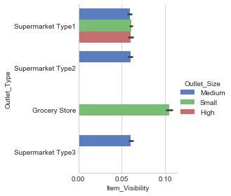

```python
sns.factorplot('Item_Visibility','Outlet_Type',hue = 'Outlet_Size',data = all_data,kind = 'bar',palette = 'muted')
```

从图中够可以看到 在grocery 中的商品可视度要明显高于其他商店 由于商品均在多个商店出售，我们以同商品在不同商店可视度的平均值作为填充值，考虑到不同商店的可视度情况，也就是说对于grocery相对要大一点，而supermarket 则相对要小一点，因此我们把Outlet_Type 考虑进去 在这里我们可以把type 分为两类 一是Grocery 第二个是Supmarket 并且 Grocery 的数据是Supmarket 的1.69倍 这可以作为我们后面填充的依据

```python
#以相同产品在不同类型商店可见度的平均值来填充

for i,row in all_data.loc[all_data['Item_Visibility']==0,:].iterrows():
    s = row['Item_Identifier']
    g = row['Outlet_Type']
    if(g == "Grocery Store"):
        #在多个 Grocery 中销售的同一个商品，在其中一个商店的值缺失  用其他Grocery 中的平均值填充
        all_data.loc[i,'Item_Visibility'] = all_data[(all_data.Item_Identifier == s)&(all_data.Outlet_Type =='Grocery Store')&(all_data.Item_Visibility != 0)].Item_Visibility.mean()


    elif g != "Grocery Store":
        #在多个 非 Grocery 中销售的同一个商品  用 非Grocery 的平均值填充
        all_data.loc[i,'Item_Visibility'] = all_data[(all_data.Item_Identifier == s)&(all_data.Outlet_Type !='Grocery Store')&(all_data.Item_Visibility != 0)].Item_Visibility.mean()
```

```python
#如果某商品 在 Grocery 中的值全部缺失  上面的处理会引入nan 那么需要用 Supmarket 的值来填充 从前面的数据可以看到 Grocery 中的值是Supermarket 的1.69倍

for i,row in all_data.loc[all_data.Item_Visibility.isnull(),:].iterrows():
    s = row['Item_Identifier']
    g = row['Outlet_Type']
    if g == 'Grocery Store' :
        # Grocery 中的数据全部缺失，用Supmarket 的平均值的1.69倍填充
        all_data.Item_Visibility.fillna((all_data[(all_data.Item_Identifier == s)&(all_data.Item_Visibility != 0)].Item_Visibility.mean()*1.69),inplace = True)
    if g != 'Grocery Store':
        # Supermarket 中的数据全部缺失 用Grocery 的平均值除以1.69 填充
            all_data.Item_Visibility.fillna((all_data[(all_data.Item_Identifier == s)&(all_data.Item_Visibility != 0)].Item_Visibility.mean()/1.69),inplace = True)
```

```python
all_data['Item_Visibility'].isnull().sum()
```

```
0
```

看一下最终的特征情况

[figure not shown]

## 三、特征处理

#### Item_Identifier

```python
all_data.Item_Identifier.head(10)
```

```
0    FDA15
1    DRC01
2    FDN15
3    FDX07
4    NCD19
5    FDP36
6    FDO10
7    FDP10
8    FDH17
9    FDU28
Name: Item_Identifier, dtype: object
```

从数据上可以发现，商品ID 的组成有两部分，前几位是字母，后面两位是数字，根据一般编码规则， 前面字母应该是类别分类，后面的数字应该是该类别下的编号，我们将这两部分分别提取出来成为两个特征。

```python
import re
def _parse_ID(s):
    s = s.strip()

    try:
        p1 = re.compile("[A-Z]+")
        p2 = re.compile("[\d]+")

        return p1.findall(s)[0],p2.findall(s)[0]
    except:
        return np.nan,np.nan
```

```python
parse_ID = pd.DataFrame(all_data.Item_Identifier.apply(lambda s:_parse_ID(s)).values.tolist(),columns = ["Item_Cat","Item_Num"])
print(parse_ID.Item_Num.isnull().sum())
print(parse_ID.Item_Cat.isnull().sum())
#说明没有缺失值
```

```
0
0
```

从Item_Cat 中再观察，可以发现，前两位只有三种 FD,DR,NC 分别表示 food,drink,none_consumable ，而最后一个字母种类比较多，应该是小类,暂时没有观察到有效信息，先保留 ，所以我们把这个字符串再拆开成两列

```python
parse_ID["Cat_1"] = pd.DataFrame(parse_ID.Item_Cat.apply(lambda s:s[:2]))
parse_ID["Cat_2"] = pd.DataFrame(parse_ID.Item_Cat.apply(lambda s:s[-1]))
```

```python
#把新创建的项目添加到原来的数据集中
all_data = pd.concat([all_data,parse_ID[["Cat_1","Cat_2","Item_Num"]]],axis =1)
```

```python
all_data.Cat_1 = all_data["Cat_1"].map({'FD':'Food', 'NC':'Non-Consumable','DR':'Drinks'})
all_data.Cat_1.value_counts()
```

```
Food              10201
Non-Consumable     2686
Drinks             1317
Name: Cat_1, dtype: int64
```

### Item_Fat_Content

```python
all_data.Item_Fat_Content.value_counts()
```

```
Low Fat    8485
Regular    4824
LF          522
reg         195
low fat     178
Name: Item_Fat_Content, dtype: int64
```

可以看到一共有五个不同类别，但是仔细查看 LF = Low Fat ,Regular = reg ,所以只有类，我们使用LF 和REG 代替原来的数据

```python
all_data.Item_Fat_Content = all_data.Item_Fat_Content.replace({"reg":"REG","Regular":"REG","low fat":"LF","Low Fat":"LF"})
```

在之前的创建出来的 Cat 中我们发现Nc对应的是家庭保健和健康等非食品类，这里我们把他们的 Fat_Content 修改为 No-Fat

```python
all_data.loc[all_data["Cat_1"] =='Non-Consumable',"Item_Fat_Content"] = 'No-Fat'
```

```python
all_data.Item_Fat_Content.value_counts()
```

```
LF        6499
REG       5019
No-Fat    2686
Name: Item_Fat_Content, dtype: int64
```

### Outlet_Establishment_Year

把商店建造年份转化为到现在（2013）运营的时间

```python
all_data["Outlet_Open_Years"] = 2013 - all_data["Outlet_Establishment_Year"]
```

```python
all_data.Outlet_Open_Years.value_counts()
```

```
28    2439
26    1553
14    1550
9     1550
16    1550
11    1548
4     1546
6     1543
15     925
Name: Outlet_Open_Years, dtype: int64
```

通过上面的处理，现在的数据已经没有缺失值和异常值了，我们这里删掉原始的一些特征，保留创建的特征

```python
all_data.drop(["Item_Identifier","Cat_2","Item_Num"],axis = 1,inplace = True)
```

```python
all_data.rename(columns = {"Cat_1":"Item_Category"},inplace = True)
```

## 四、数据可视化

### 4.1 店铺层面

店铺方面的数据一共有 'Outlet_Type', 'Outlet_Location_Type','Outlet_Type','Outlet_Open_Years' 四个特征

##### Outlet_Type

[figure not shown]

```python
fig,axes = plt.subplots(0,0)
fig.set_size_inches(10,10)
g = sns.boxplot(x = 'Outlet_Type', y ='Item_Outlet_Sales',data = all_data)
```

不同商店类型的销售额差距明显 sup 3>sup 1 > sup 2> grocery store，是作为预测销售额的重要特征

##### Outlet_Size

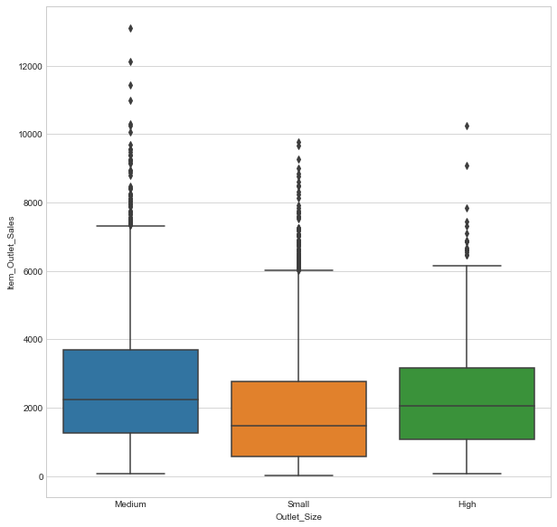

```python
fig ,axes = plt.subplots(1,1)
fig.set_size_inches(10,10)
sns.boxplot("Outlet_Size","Item_Outlet_Sales",data = all_data)
```

商店的规模大小对销售额有划分，但是不随着规模增长

##### Outlet_Location_Type

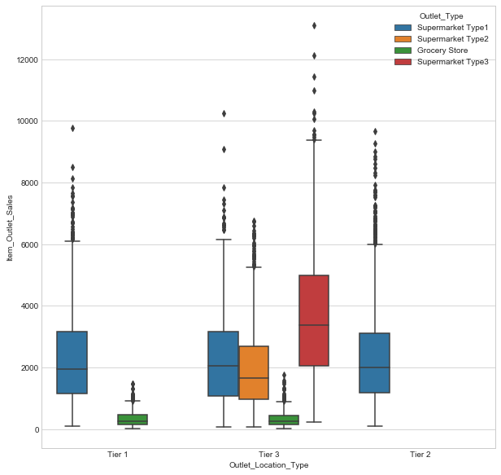

```python
fig ,axes = plt.subplots(1,1)
fig.set_size_inches(10,10)
sns.boxplot("Outlet_Location_Type","Item_Outlet_Sales",data = all_data,hue = 'Outlet_Type')
```

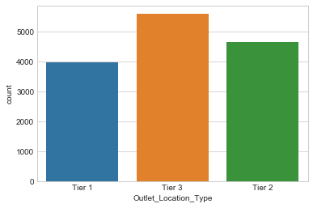

```python
sns.countplot("Outlet_Location_Type",data = all_data)
```

商店位置方面，位置3 的数量最多，类型也最完整，其他地区商店类型单一，销售额与位置因素关系不明显

##### Outlet_Open_Years

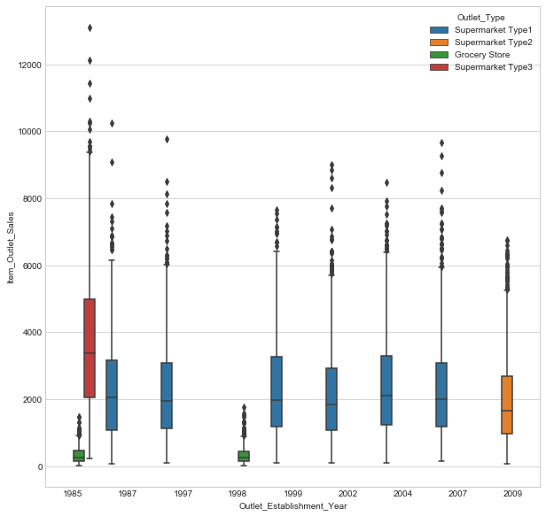

```python
fig ,axes = plt.subplots(1,1)
fig.set_size_inches(10,10)
g = sns.boxplot("Outlet_Establishment_Year","Item_Outlet_Sales",data = all_data , hue = 'Outlet_Type')
```

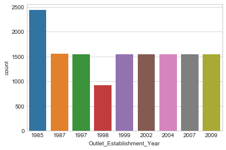

```python
sns.countplot(x = 'Outlet_Establishment_Year',data = all_data)
```

不同年份的销售额平均值基本稳定在2000 但还是略有波动

### 4.2 商品层面

#### Item_Category

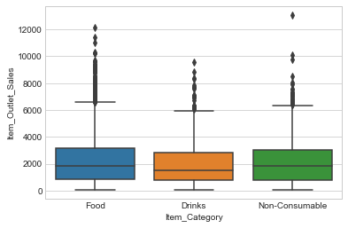

```python
type_list = list(all_data.Outlet_Type.unique())
sns.boxplot(x = 'Item_Category',y = 'Item_Outlet_Sales',data = all_data)
```

不同类别的商品销售额不同，food 和 Non-Consumable 基本持平，drinks 略低一点

#### Item_Weight

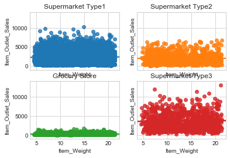

```python
# sns.lmplot(x = 'Item_Weight',y = 'Item_Outlet_Sales',data = all_data,col='Outlet_Type',hue = 'Outlet_Type')
# %pylab inline
# pylab.rcParams['figure.figsize'] = (10, 10)

fig, axes = plt.subplots(nrows=2, ncols=2,sharex = True,sharey =True)
ax0, ax1, ax2, ax3 = axes.flatten()
for ax,col in zip(axes.flatten(),type_list):
    sns.regplot(x = 'Item_Weight',y = 'Item_Outlet_Sales',data = all_data[all_data.Outlet_Type == col],ax= ax)
    ax.set_title(col)
```

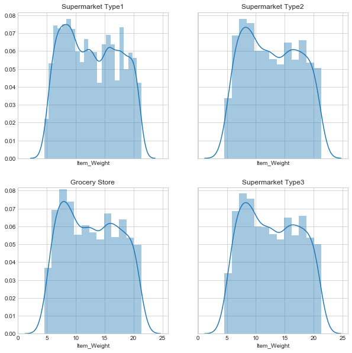

```python
%pylab inline
pylab.rcParams['figure.figsize'] = (10, 10)

fig, axes = plt.subplots(nrows=2, ncols=2,sharex = True,sharey =True)
ax0, ax1, ax2, ax3 = axes.flatten()
for ax,col in zip(axes.flatten(),type_list):
    data = all_data[all_data['Outlet_Type'] == col]
    sns.distplot(data['Item_Weight'],ax = ax)
    ax.set_title(col)
```

#### Item_Fat_Content

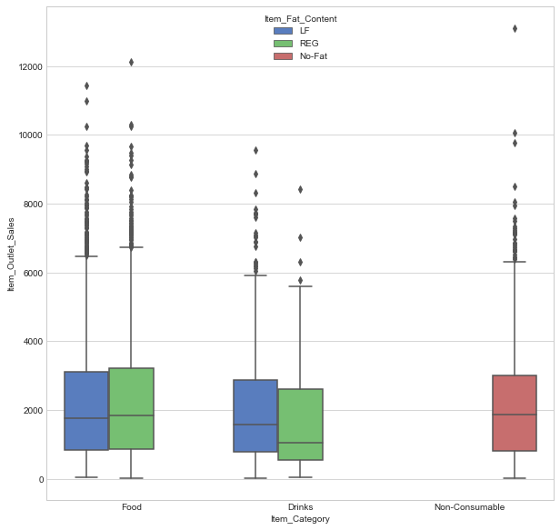

```python
sns.boxplot('Item_Category','Item_Outlet_Sales',data = all_data,hue = 'Item_Fat_Content',palette ='muted')
```

不同类型商品中，脂肪含量的影响不同 食品类和非食品类销售额相对饮品的销售额高一点

#### Item_Type

```python
typelist = all_data.Item_Type.unique()  # 图中的标签
typelist
```

```
array(['Dairy', 'Soft Drinks', 'Meat', 'Fruits and Vegetables',
       'Household', 'Baking Goods', 'Snack Foods', 'Frozen Foods',
       'Breakfast', 'Health and Hygiene', 'Hard Drinks', 'Canned',
       'Breads', 'Starchy Foods', 'Others', 'Seafood'], dtype=object)
```

[output not shown]

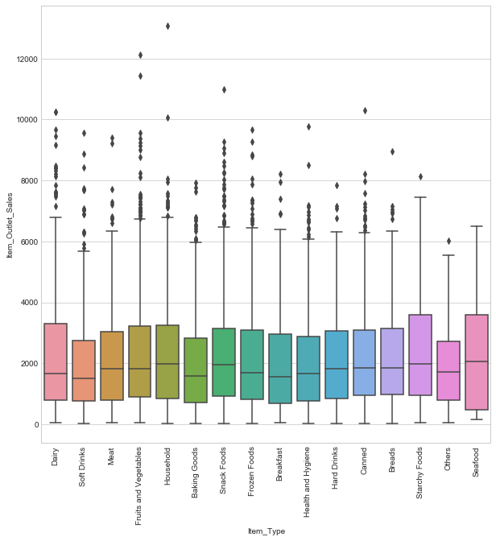

```python
fig, axes = plt.subplots(1,1)
g = sns.boxplot(x = 'Item_Type',y = 'Item_Outlet_Sales',data = all_data,ax= axes)
g.set_xticklabels(labels = typelist,rotation=90)
```

不同种类的销售额不同，具有一定的区分性

#### Item_Fat_Content

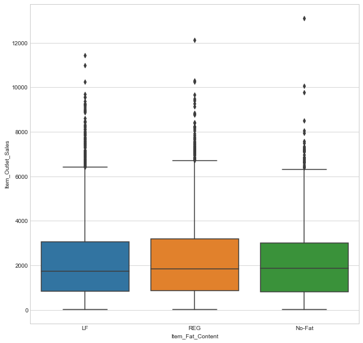

```python
g = sns.boxplot(x = 'Item_Fat_Content',y = 'Item_Outlet_Sales',data = all_data)
```

脂含量方面，不同脂含量之间的销售额并没有明显差距

#### Item_Visibility

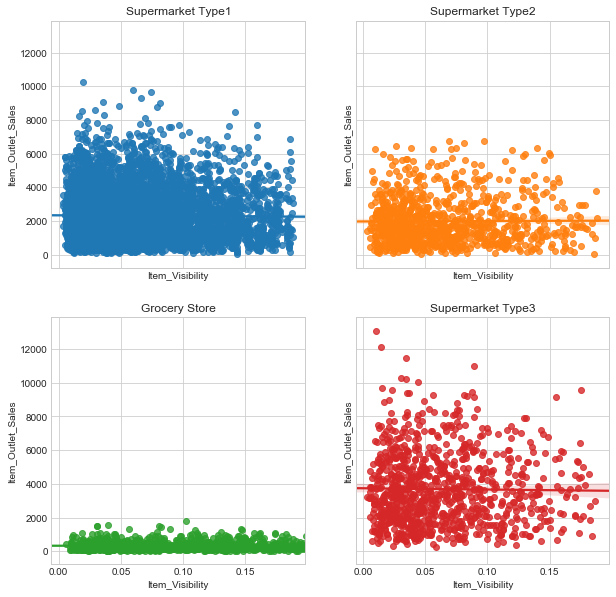

```python
fig,axes = plt.subplots(2,2,sharex = True,sharey =True)
ax0,ax1,ax2,ax3 = axes.flatten()

for ax, col in zip(axes.flatten(),type_list):
    sns.regplot(x = 'Item_Visibility',y = 'Item_Outlet_Sales',data = all_data[all_data.Outlet_Type == col],ax= ax)
    ax.set_title(col)
```

#### Item_MRP

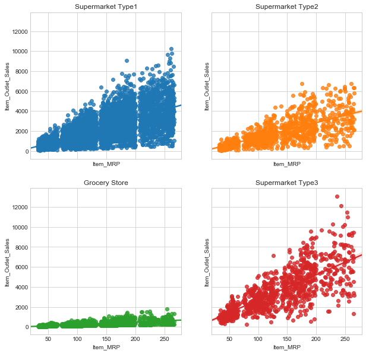

```python
fig,axes = plt.subplots(2,2,sharex = True,sharey =True)
ax0,ax1,ax2,ax3 = axes.flatten()

for ax, col in zip(axes.flatten(),type_list):
    sns.regplot(x = 'Item_MRP',y = 'Item_Outlet_Sales',data = all_data[all_data.Outlet_Type == col],ax= ax)
    ax.set_title(col)
```

销售额与定价基本成正比的关系，不同类型商店的销量（斜率）各不相同

## 五、特征工程

```python
# feature_DF = all_data['Item_Fat_Content','Item_Type','Outlet_Size','Outlet_Location_Type']
features = pd.get_dummies(all_data.iloc[:,[1,3,7,8,9,11,12]])
```

```python
all_data.head()
```

|  | Item_Weight | Item_Fat_Content | Item_Visibility | Item_Type | Item_MRP | Outlet_Identifier | Outlet_Establishment_Year | Outlet_Size | Outlet_Location_Type | Outlet_Type | Item_Outlet_Sales | Item_Category | Outlet_Open_Years |
| --- | --- | --- | --- | --- | --- | --- | --- | --- | --- | --- | --- | --- | --- |
| 0 | 9.30 | LF | 0.016047 | Dairy | 249.8092 | OUT049 | 1999 | Medium | Tier 1 | Supermarket Type1 | 3735.1380 | Food | 14 |
| 1 | 5.92 | REG | 0.019278 | Soft Drinks | 48.2692 | OUT018 | 2009 | Medium | Tier 3 | Supermarket Type2 | 443.4228 | Drinks | 4 |
| 2 | 17.50 | LF | 0.016760 | Meat | 141.6180 | OUT049 | 1999 | Medium | Tier 1 | Supermarket Type1 | 2097.2700 | Food | 14 |
| 3 | 19.20 | REG | 0.038751 | Fruits and Vegetables | 182.0950 | OUT010 | 1998 | Small | Tier 3 | Grocery Store | 732.3800 | Food | 15 |
| 4 | 8.93 | No-Fat | 0.013192 | Household | 53.8614 | OUT013 | 1987 | High | Tier 3 | Supermarket Type1 | 994.7052 | Non-Consumable | 26 |

```python
add_features = all_data.iloc[:,[10,2,4,0]]
vis_mrp = all_data.iloc
features = pd.concat([add_features,features],axis = 1)
result= all_data.iloc[:,10]
```

```python
df = features.corr()
df.Item_Outlet_Sales.sort_values(ascending = False)
```

```
Item_Outlet_Sales                  1.000000
Item_MRP                           0.567574
Outlet_Type_Supermarket Type3      0.311192
Outlet_Size_Medium                 0.204701
Outlet_Type_Supermarket Type1      0.108765
Outlet_Location_Type_Tier 2        0.058261
Outlet_Open_Years                  0.049135
Outlet_Location_Type_Tier 3        0.046376
Item_Category_Food                 0.031905
Item_Type_Fruits and Vegetables    0.025950
Outlet_Size_High                   0.024170
Item_Type_Snack Foods              0.022782
Item_Fat_Content_REG               0.018719
Item_Type_Household                0.015701
Item_Type_Starchy Foods            0.015039
Item_Weight                        0.013261
Item_Type_Dairy                    0.008858
Item_Type_Canned                   0.007387
Item_Type_Seafood                  0.007380
Item_Type_Breads                   0.002332
Item_Type_Meat                    -0.002995
Item_Type_Hard Drinks             -0.003956
Item_Type_Breakfast               -0.004656
Item_Fat_Content_LF               -0.009438
Item_Type_Frozen Foods            -0.009482
Item_Fat_Content_No-Fat           -0.010861
Item_Category_Non-Consumable      -0.010861
Item_Type_Others                  -0.021267
Item_Type_Soft Drinks             -0.024040
Item_Type_Health and Hygiene      -0.025587
Item_Category_Drinks              -0.034672
Outlet_Type_Supermarket Type2     -0.038059
Item_Type_Baking Goods            -0.038381
Outlet_Location_Type_Tier 1       -0.111287
Item_Visibility                   -0.131226
Outlet_Size_Small                 -0.208912
Outlet_Type_Grocery Store         -0.411727
Name: Item_Outlet_Sales, dtype: float64
```

通过以上数据我们最终选择的特征有 Item_Visibility、Item_MRP、Item_Type、Item_Category、Outlet_Type 、 Outlet_Size 、Outlet_Open_Years、Outlet_Location_Type

```python
features.head(1)
```

|  | Item_Outlet_Sales | Item_Visibility | Item_MRP | Item_Weight | Outlet_Open_Years | Item_Fat_Content_LF | Item_Fat_Content_No-Fat | Item_Fat_Content_REG | Item_Type_Baking Goods | Item_Type_Breads | ... | Outlet_Location_Type_Tier 1 | Outlet_Location_Type_Tier 2 | Outlet_Location_Type_Tier 3 | Outlet_Type_Grocery Store | Outlet_Type_Supermarket Type1 | Outlet_Type_Supermarket Type2 | Outlet_Type_Supermarket Type3 | Item_Category_Drinks | Item_Category_Food | Item_Category_Non-Consumable |
| --- | --- | --- | --- | --- | --- | --- | --- | --- | --- | --- | --- | --- | --- | --- | --- | --- | --- | --- | --- | --- | --- |
| 0 | 3735.138 | 0.016047 | 249.8092 | 9.3 | 14 | 1 | 0 | 0 | 0 | 0 | ... | 1 | 0 | 0 | 0 | 1 | 0 | 0 | 0 | 1 | 0 |

1 rows × 37 columns

```python
df= all_data.loc[:,['Item_Type','Item_Category','Outlet_Type','Outlet_Size','Outlet_Open_Years','Outlet_Location_Type']]
```

```python
cat_feature_df = pd.get_dummies(df)

bad = pd.concat([result,cat_feature_df],axis = 1)

bad['vis'] = all_data.Item_Visibility*10
bad['MRP'] = all_data.Item_MRP
```

## 六、结果预测

```python
# from sklearn.cross_validation import train_test_split
#随机森林Random Forests Model
from sklearn.ensemble import RandomForestRegressor


model = RandomForestRegressor(n_estimators=100)
```

```python
source_X_bad = bad.iloc[:8523,1:]
source_y_bad = bad.iloc[:8523,0]
pred_X_bad = bad.iloc[8523:,1:]
```

```python
# 构建训练集和验证集  防止过拟合   TO DO
# #建立模型用的训练数据集和测试数据集
# train_X, test_X, train_y, test_y = train_test_split(source_X ,
#                                                     source_y,
#                                                     train_size=.8)
```

```python
# #输出数据集大小
# print ('原始数据集特征：',source_X.shape,
#        '训练数据集特征：',train_X.shape ,
#        '测试数据集特征：',test_X.shape)

# print ('原始数据集标签：',source_y.shape,
#        '训练数据集标签：',train_y.shape ,
#        '测试数据集标签：',test_y.shape)
```

```python
model.fit(source_X_bad,source_y_bad)
prediction_bad = model.predict(pred_X_bad)
ge = test_raw.iloc[:,[0,6]]    #组中结果的索引
ge["Item_Outlet_Sales"] = np.around(prediction_bad,2)
ge.to_csv("D:/Projects/AnacondaProjects/bigmart_bad.csv",index=False)
```